# STA 317 Homework #1

Scott Girten

## Problem 1

Consider two random variables, X and Y. Suppose $E(X) = 6$, $var(X) = 9$, $E(Y) = 0$, $var(Y) = 4$ and $corr(X,Y) = 0.25$. Find the following, showing all your steps:

```r
covXY = 0.25 * sqrt(9 * 4)
```

### Part A: $Var(X + Y)$

$corr(x,Y) = \frac{cov(x,Y)}{\sqrt{var(X)var(Y)}}$

$cov(X,Y) = corr(X,Y)*\sqrt{var(X)var(Y)}$

$var(X + Y) = Var(X) + Var(Y) + 2cov(X,Y)$

$var(X + Y) = Var(X) + Var(Y) +2corr(X,Y)\sqrt{var(X)var(Y)}$

$var(X + Y) = 9 + 4 + 2(1.5)$

$var(X + Y) = 16$

### Part B: $cov(X,X + 2Y)$

$cov(X,X+2Y) = cov(X,X) + cov(X,2Y)$

$cov(X,X+2Y) = Var(X) +2cov(X,Y)$

$cov(X,X+2Y) = 9 + 2(1.5)$

$cov(X,X+2Y) = 12$

### Part C: $corr(X+Y,X-Y)$

$corr(X+Y,X-Y) = \frac{cov(X+Y, X-Y)}{\sqrt{Var(X+Y)Var(X-Y)}}$

> $cov(X+Y, X-Y) = cov(X,X) - cov(X,Y) + cov(Y,X) - cov(Y,Y)$

> $cov(X+Y, X-Y) = Var(X) - Var(Y)$

> $cov(X+Y, X-Y) = 9 - 4 = 5$

> $Var(X+Y)Var(X-Y) = (Var(X)+Var(Y)+2cov(X,Y))(Var(X)+Var(Y)-2cov(X,Y))$

> $Var(X+Y)Var(X-Y) = (9+4+2(1.5))(9+4-2(1.5))$

> $Var(X+Y)Var(X-Y) = 160$

$corr(X+Y,X-Y) = \frac{5}{\sqrt{160}}$

$corr(X+Y,X-Y) = 0.3952847$

## Problem 2

Construct a time series plot in R. Write a brief description of the patterns you see. For example, do certain months tend to have high $CO_2$ values? What about lowest values? To assist in your graph, use the following commands to include monthly plotting symbols.

The pattern from the CO2 data shows an increasing channel from the 1960’s through the 1990’s.

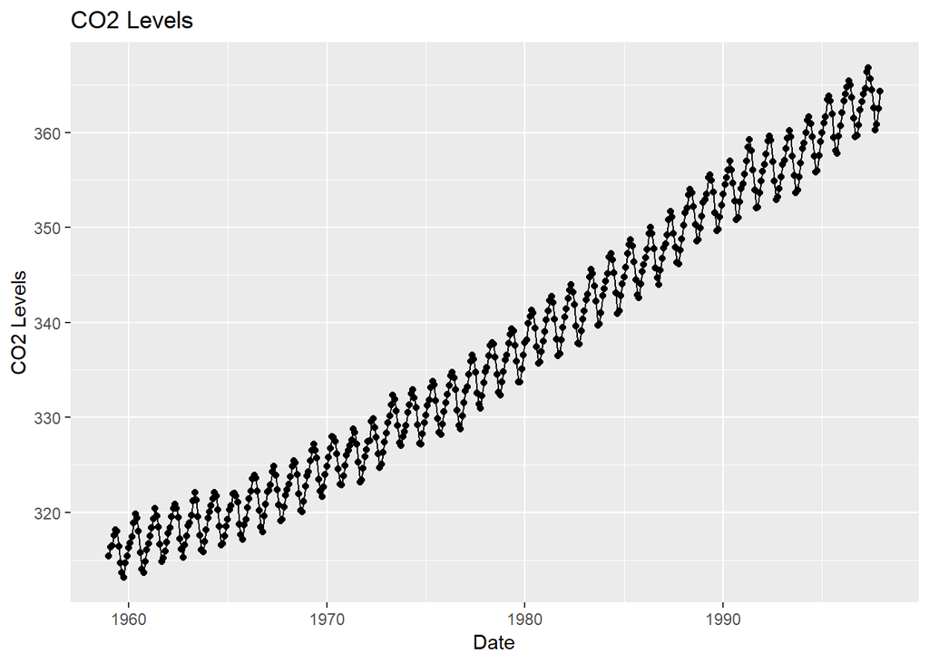

```r
library(tidyverse)
library(TSA)
library(timetk)
library(gghighlight)
library(ggfortify)

co2_data = timetk::tk_tbl(co2) %>%
  mutate(Month = lubridate::month(index))

co2_ggplot = ggplot(co2_data, aes(x = index, y = value)) +
  geom_point() +
  geom_line() +
  scale_x_continuous() +
  ggtitle("CO2 Levels") +
  xlab("Date") +
  ylab("CO2 Levels")
plot(co2_ggplot)
```

```r
#plotly::ggplotly(co2_ggplot)
```

The graph below highlights the months March, April and May as having the highest CO2 levels.

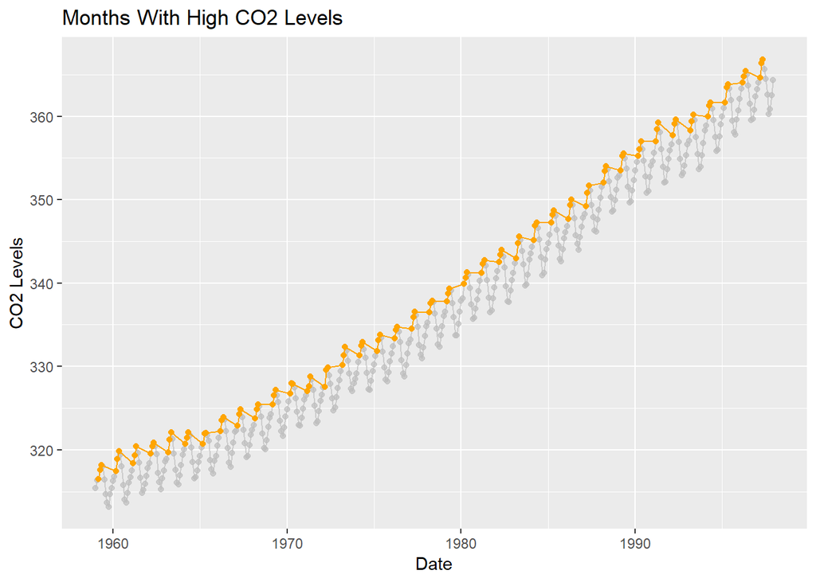

```r
co2_ggplot_high = ggplot(co2_data, aes(x = index, y = value)) +
  geom_point(color = "orange") +
  geom_line(color = "orange") +
  scale_x_continuous() +
  ggtitle("Months With High CO2 Levels") +
  xlab("Date") +
  ylab("CO2 Levels") +
  gghighlight(Month %in% c(3, 4, 5))
plot(co2_ggplot_high)
```

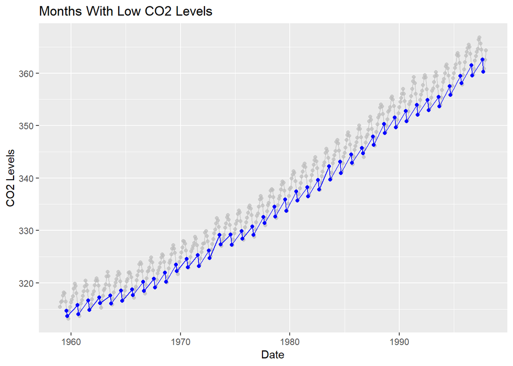

```r
co2_ggplot_low = ggplot(co2_data, aes(x = index, y = value)) +
  geom_point(color = "blue") +
  geom_line(color = "blue") +
  scale_x_continuous() +
  ggtitle("Months With Low CO2 Levels") +
  xlab("Date") +
  ylab("CO2 Levels") +
  gghighlight(Month %in% c(8, 9))
plot(co2_ggplot_low)
```

## Problem 3

Simulations of white noise processes

### Part A

Simulate and plot a white noise process where $Y_t \approx$ Normal (mean = 0, st.dev. = 1). These are independent and identically distributed.

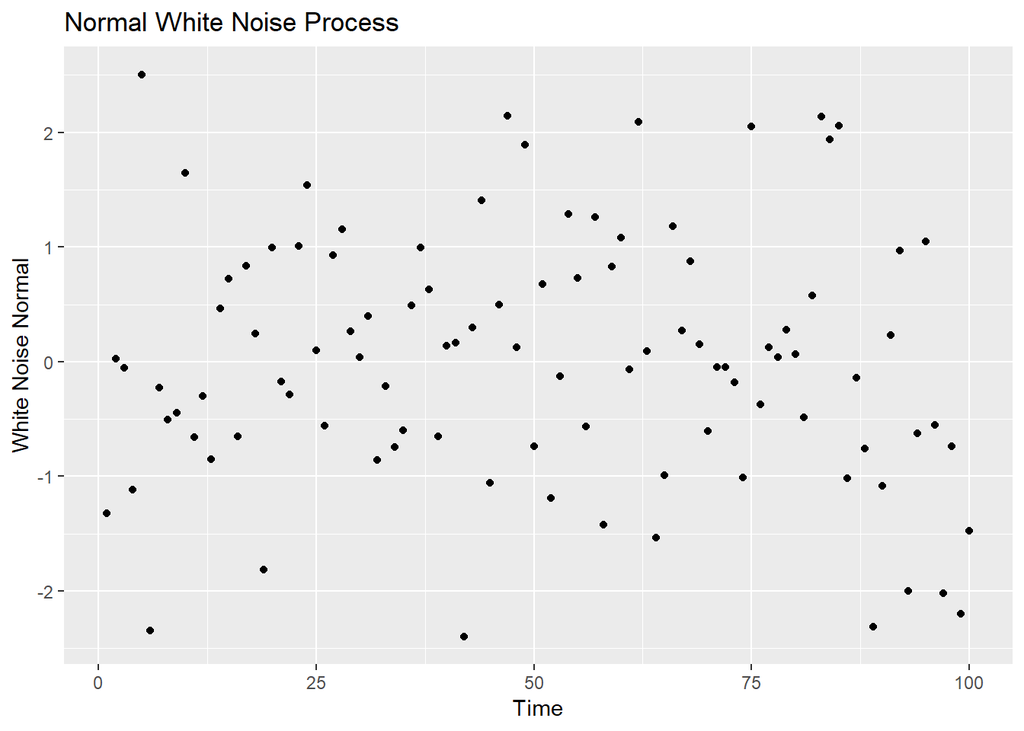

```r
time_index = (1:100)
y100n = rnorm(100, 0, 1) # n = 100, mean = 0 and st. dev. = 1
y100n_df = tibble(time_index, y100n)
#plot(y100n, ylab = "White Noise Normal 0-1", xlab = "Time")

y100n_plot = ggplot(y100n_df, aes(x = time_index, y = y100n)) +
  geom_point() +
  xlab("Time") +
  ylab("White Noise Normal") +
  ggtitle("Normal White Noise Process")
plot(y100n_plot)
```

### Part B

Simulate and plot a white noise process where $Y_t \approx T$ with 1 degree of freedom. These are independent and identically distributed. This is the Cauchy distribution, known to produce outliers on occasion.

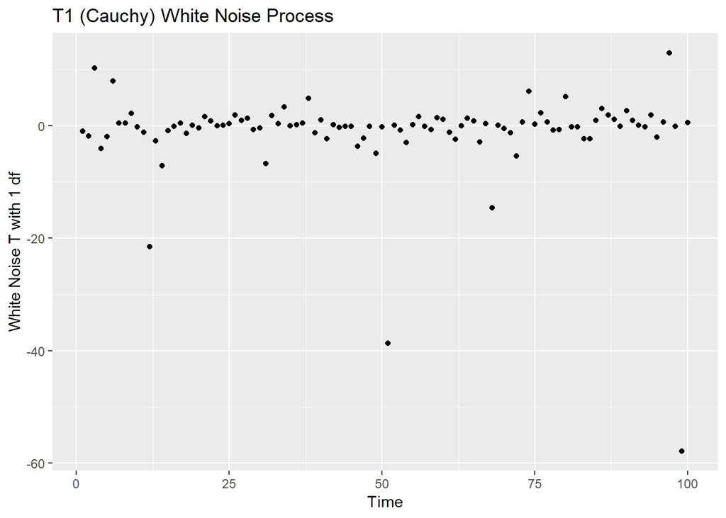

```r
y100t = rt(100, 1) # n = 100, t with 1 degree of freedom
#plot(y100t)

y100t_df = tibble(time_index, y100t)

y100t_plot = ggplot(y100t_df, aes(x = time_index, y = y100t)) +
  geom_point() +
  xlab("Time") +
  ylab("White Noise T with 1 df") +
  ggtitle("T1 (Cauchy) White Noise Process")
plot(y100t_plot)
```

### Part C

Simulate and plot a white noise process where $Y_t \approx$ Chi-square with 5 degrees of freedom. These are independent and identically distributed.

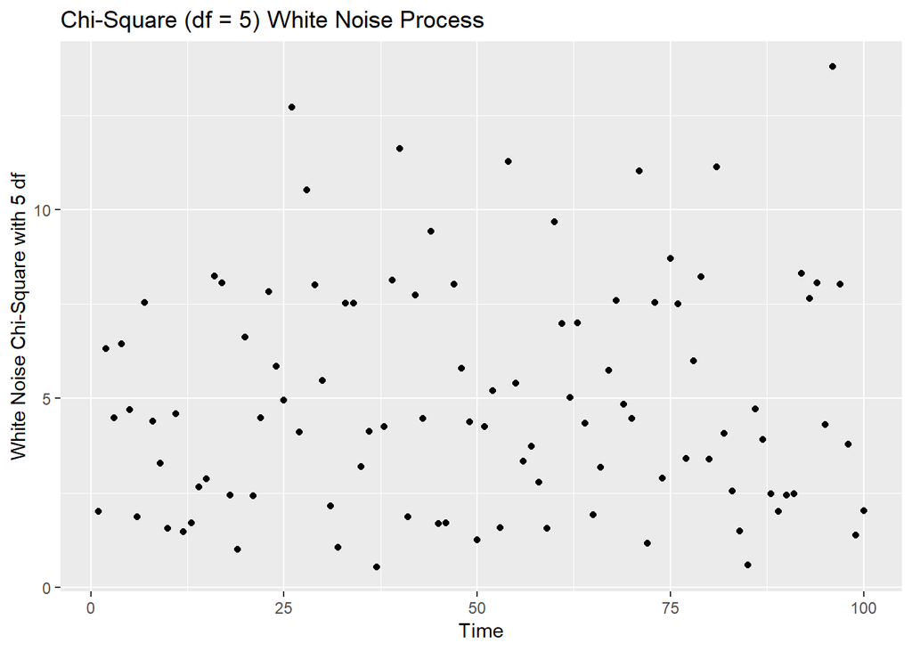

```r
y100chi = rchisq(100, 5) # n = 100, chi-square with df = 5
#plot(y100chi)

y100chi_df = tibble(time_index, y100chi)

y100chi_plot = ggplot(y100chi_df, aes(x = time_index, y = y100chi)) +
  geom_point() +
  xlab("Time") +
  ylab("White Noise Chi-Square with 5 df") +
  ggtitle("Chi-Square (df = 5) White Noise Process")
plot(y100chi_plot)
```